# Predicting Housing Prices in California

Alexandra Hernandez, Eldrick Dean Solano, Arielle Ho, Ethan Lin

## Introduction

With a population of approximately 39 million, California continues to symbolize opportunity and innovation, attracting people from across the nation and around the world[^1]. Counties such as the Central Valley, Bay Area, Inland Empire, Los Angeles, and Orange County have experienced notable population surges. However, only five cities within these regions have seen substantial increases, bypassing more traditional urban hubs[^2]. This trend coincides with skyrocketing housing costs—San Francisco’s average home value, for instance, has climbed to an astonishing $1,262,234[^3].

Historically, California has been one of the most desirable places to live, largely due to its economic opportunities. With the largest GDP in the United States—and the fifth largest globally, at $3.9 trillion in 2023[^4]—the state draws individuals seeking diverse job prospects across industries such as technology, entertainment, and agriculture. Yet, these opportunities come at a cost: California faces a high cost of living (HCOL) and a severe housing shortage, particularly in its urbanized areas. As the demand for housing in cities continues to outpace supply, more residents are turning to suburban areas, reshaping the state’s housing landscape and intensifying debates over affordability, equity, and sustainable development.

Becky Nicolaides’s *The New Suburbia: How Diversity Remade Suburban Life in Los Angeles after 1945* (2023) provides valuable historical context for this shift. According to Nicolaides, Los Angeles adopted a “suburban identity” by the 1940s to accommodate a growing population fueled by WWII and the Baby Boom. City leaders throughout the county pursued decentralized development, creating what Nicolaides describes as “borderlands, streetcar suburbs, edge cities, and corporate suburbs” (Nicolaides, 2023)[^5]. These initiatives left a blueprint for accommodating those who sought proximity to urban centers without incurring the high costs associated with city living. Today, much of California’s population resides in suburban areas, commuting to nearby urban centers for work, entertainment, and other activities.

The significance of this research lies in its practical application: with housing affordability becoming an increasingly urgent issue, this projects provides insight in navigating California’s complicated housing market. By examining geographical and economic data, this project aims to pinpoint possible locations for buying and owning a home without breaking the bank, all while having ideal traits and examining current housing market trends.

## Question

How accurately can housing prices in California be predicted based on geographical factors and regional population dynamics?

### Load packages

Here we load the respective packages `tidyverse`, `tidymodels`, `olsrr`, and `conflicted` to handle cleaning, analysis, modeling, and predicting aspects of the data.

```r
#install.packages("maps")
library(tidyverse)
library(tidymodels)
library(olsrr)
library(conflicted)
library(scales)
library(maps)

conflict_prefer("filter", "dplyr")
conflict_prefer("select", "dplyr")
```

## The Data

The data that we’re examining for the question is an Updated California Housing Prices dataset, which contains information gathered from the US Census Bureau from 2009-2020. The data contains 11 variables, which are `name`, `total_population`, `total_households`, `average_household_income`, `average_house_age`, `total_rooms`, `total_bedrooms`, `median_house_value`, `longitude`, `latitude`, and `ocean_proximity`. The original data card can be found on [kaggle.com](https://www.kaggle.com/datasets/ebelmagnin/housing/data)

### Data Import

We import the data using `read_csv()`. The data can be found under the `data` directory of this repository.

Here are a few summary statistics of the original data import.

```r
summary(ca_housing)
```

```
##      name           total_population total_households average_household_income
##  Length:25591       Min.   :    0    Min.   :   0.0   Min.   :     0
##  Class :character   1st Qu.: 1009    1st Qu.: 348.0   1st Qu.: 66178
##  Mode  :character   Median : 1421    Median : 475.0   Median : 89021
##                     Mean   : 1537    Mean   : 512.0   Mean   : 92005
##                     3rd Qu.: 1940    3rd Qu.: 640.5   3rd Qu.:115610
##                     Max.   :39373    Max.   :7133.0   Max.   :212500
##
##  average_house_age  total_rooms         total_bedrooms   median_house_value
##  Min.   : 0.00     Min.   :-666666666   Min.   :   0.0   Min.   :-666666666
##  1st Qu.:21.60     1st Qu.:      1908   1st Qu.: 376.0   1st Qu.:    298400
##  Median :26.90     Median :      2639   Median : 514.0   Median :    481400
##  Mean   :26.51     Mean   :  -3388202   Mean   : 555.3   Mean   : -62367652
##  3rd Qu.:32.10     3rd Qu.:      3634   3rd Qu.: 694.0   3rd Qu.:    735150
##  Max.   :45.50     Max.   :     46497   Max.   :7960.0   Max.   :   2000001
##                    NA's   :34
##    longitude         latitude     ocean_proximity
##  Min.   :-124.2   Min.   :32.55   Length:25591
##  1st Qu.:-121.6   1st Qu.:33.93   Class :character
##  Median :-118.6   Median :34.26   Mode  :character
##  Mean   :-119.5   Mean   :35.54
##  3rd Qu.:-118.0   3rd Qu.:37.68
##  Max.   :-114.3   Max.   :41.75
##
```

```r
ca_housing
```

```
## # A tibble: 25,591 × 11
##    name           total_population total_households average_household_income
##    <chr>                     <dbl>            <dbl>                    <dbl>
##  1 Alameda County             1713              644                  150520.
##  2 Alameda County             1322              630                  167222.
##  3 Alameda County              940              417                  171948.
##  4 Alameda County             1043              413                  150914.
##  5 Alameda County             1206              423                  167677.
##  6 Alameda County             1318              775                  122429.
##  7 Alameda County             1076              590                   79110.
##  8 Alameda County             1458              631                  143221.
##  9 Alameda County             1544              706                  124129.
## 10 Alameda County              885              443                  118708.
## # ℹ 25,581 more rows
## # ℹ 7 more variables: average_house_age <dbl>, total_rooms <dbl>,
## #   total_bedrooms <dbl>, median_house_value <dbl>, longitude <dbl>,
## #   latitude <dbl>, ocean_proximity <chr>
```

### Data Wrangling

```r
# Dropping all the rows that contain the value -666666666
ca_housing <- ca_housing[!apply(ca_housing == -666666666, 1, any), ]
skimr::skim(ca_housing)
```

Data summary

| Name | ca_housing |
| --- | --- |
| Number of rows | 23175 |
| Number of columns | 11 |
| _______________________ |  |
| Column type frequency: |  |
| character | 2 |
| numeric | 9 |
| ________________________ |  |
| Group variables | None |

**Variable type: character**

| skim_variable | n_missing | complete_rate | min | max | empty | n_unique | whitespace |
| --- | --- | --- | --- | --- | --- | --- | --- |
| name | 0 | 1 | 11 | 22 | 0 | 58 | 0 |
| ocean_proximity | 0 | 1 | 6 | 10 | 0 | 4 | 0 |

**Variable type: numeric**

| skim_variable | n_missing | complete_rate | mean | sd | p0 | p25 | p50 | p75 | p100 | hist |
| --- | --- | --- | --- | --- | --- | --- | --- | --- | --- | --- |
| total_population | 0 | 1 | 1558.52 | 712.18 | 26.00 | 1035.00 | 1447.00 | 1962.00 | 9793.00 | ▇▂▁▁▁ |
| total_households | 0 | 1 | 518.68 | 225.45 | 18.00 | 355.00 | 480.00 | 645.50 | 3465.00 | ▇▂▁▁▁ |
| average_household_income | 0 | 1 | 95206.56 | 32698.05 | 12563.83 | 69637.62 | 92172.39 | 117990.33 | 212500.00 | ▂▇▇▂▁ |
| average_house_age | 0 | 1 | 26.70 | 7.56 | 3.50 | 21.70 | 27.10 | 32.20 | 45.50 | ▁▃▇▇▂ |
| total_rooms | 0 | 1 | 3018.50 | 1405.95 | 73.00 | 2013.00 | 2747.00 | 3744.00 | 16777.00 | ▇▃▁▁▁ |
| total_bedrooms | 0 | 1 | 561.24 | 244.37 | 18.00 | 382.00 | 519.00 | 698.00 | 3577.00 | ▇▂▁▁▁ |
| median_house_value | 0 | 1 | 630683.07 | 410368.30 | 9999.00 | 355700.00 | 532300.00 | 785650.00 | 2000001.00 | ▆▇▃▁▁ |
| longitude | 0 | 1 | -119.51 | 1.97 | -124.16 | -121.72 | -118.66 | -117.95 | -114.35 | ▂▆▅▇▁ |
| latitude | 0 | 1 | 35.56 | 2.08 | 32.55 | 33.93 | 34.27 | 37.69 | 41.75 | ▇▁▅▂▁ |

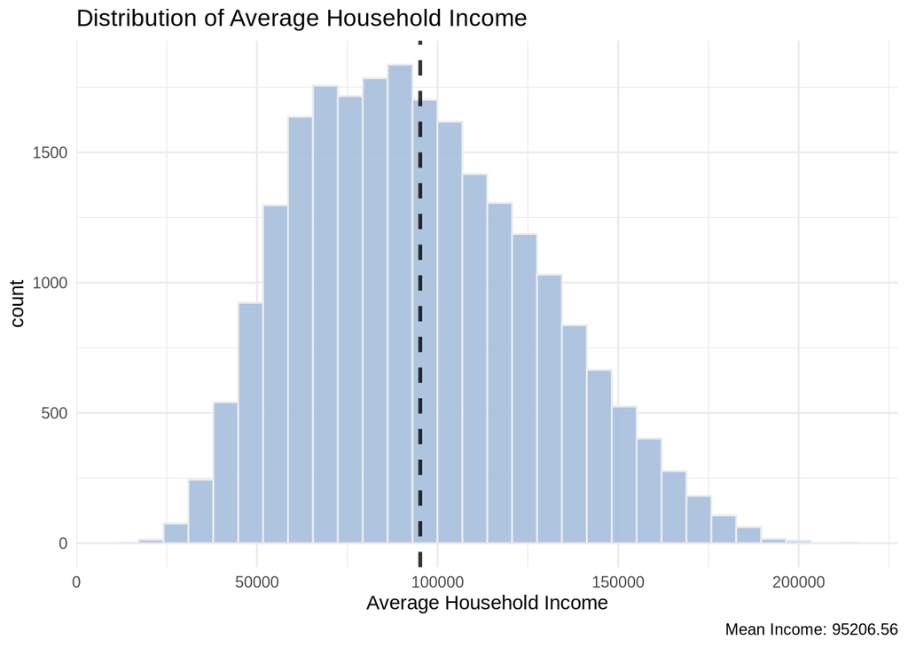

```r
mean_income <- mean(ca_housing$average_household_income, na.rm = TRUE)

avg_income_distribution <- ggplot(ca_housing, aes(x = average_household_income)) +
  geom_histogram(fill="#a6bddb", color="#e9ecef", alpha=0.9) +
  geom_vline(aes(xintercept = mean_income),
             color = "black", linetype = "dashed", size = 1, alpha = 0.8) +
  labs(title = "Distribution of Average Household Income",
       x = "Average Household Income",
       caption = paste("Mean Income:", round(mean_income, 2))) +
  theme_minimal()

show(avg_income_distribution)
```

In this visualization, we see that the average household income is overall balanced, with a slight right skew. The average household income for all data points in the dataset is $95,206.56.

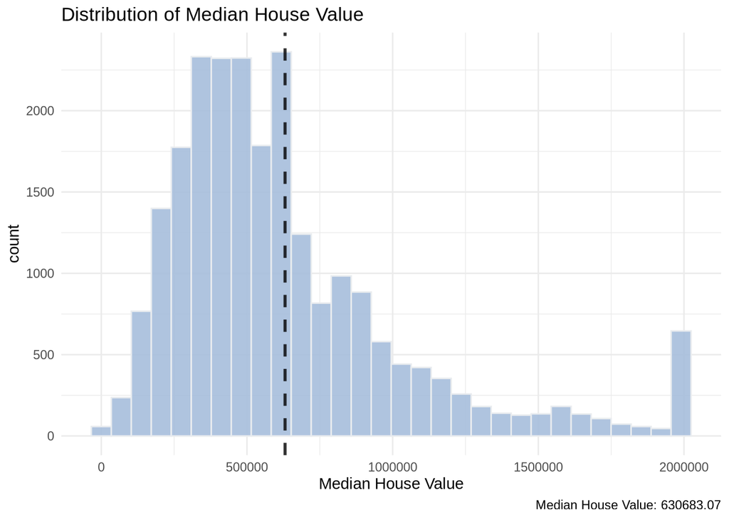

```r
mean_house <- mean(ca_housing$median_house_value, na.rm = TRUE)

avg_value_distribution <- ggplot(ca_housing, aes(x = median_house_value)) +
  geom_histogram(fill="#a6bddb", color="#e9ecef", alpha=0.9) +
  geom_vline(aes(xintercept = mean_house),
             color = "black", linetype = "dashed", size = 1, alpha = 0.8) +
  labs(title = "Distribution of Median House Value",
       x = "Median House Value",
       caption = paste("Median House Value:", round(mean_house, 2))) +
  theme_minimal()

show(avg_value_distribution)
```

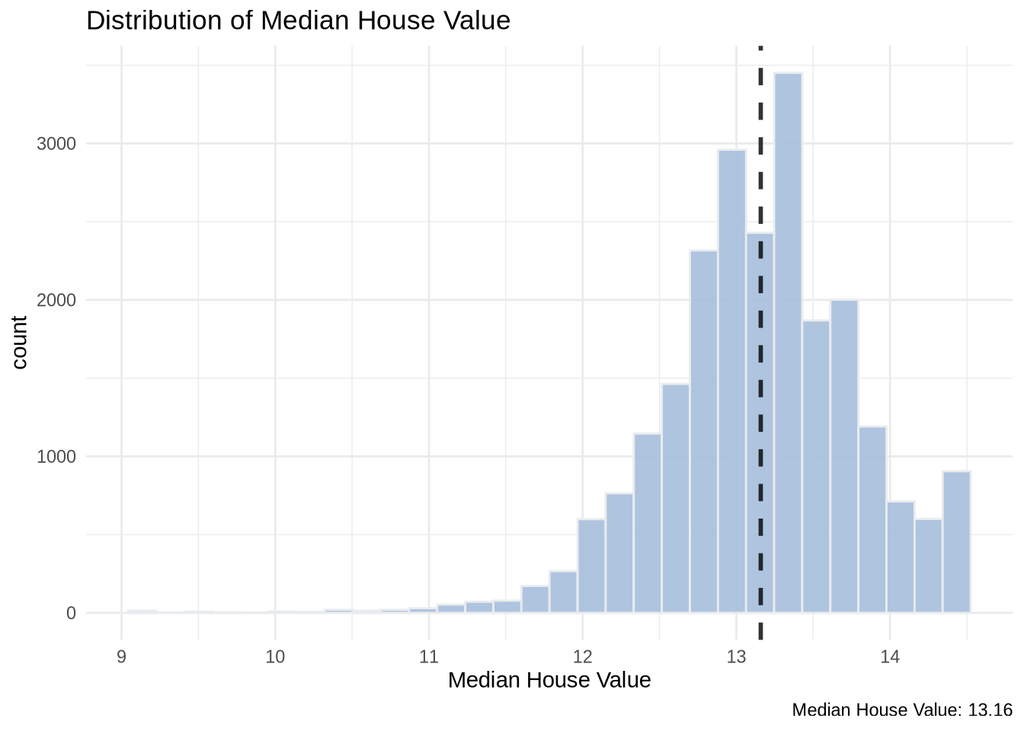

```r
mean_house <- mean(log(ca_housing$median_house_value), na.rm = TRUE)

avg_value_distribution <- ggplot(ca_housing, aes(x = log(median_house_value))) +
  geom_histogram(fill="#a6bddb", color="#e9ecef", alpha=0.9) +
  geom_vline(aes(xintercept = mean_house),
             color = "black", linetype = "dashed", size = 1, alpha = 0.8) +
  labs(title = "Distribution of Median House Value",
       x = "Median House Value",
       caption = paste("Median House Value:", round(mean_house, 2))) +
  theme_minimal()

show(avg_value_distribution)
```

When we log-transform the median house value, we get a much more normal distribution, which is easier to work with.

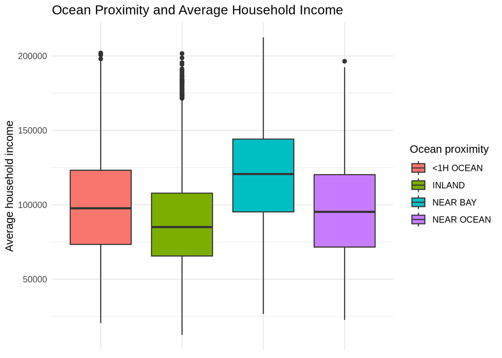

```r
ocean_prox_avg_house_income <- ggplot(ca_housing, aes(x = ocean_proximity, y = average_household_income, fill = ocean_proximity)) +
  geom_boxplot() +
  labs(title = "Ocean Proximity and Average Household Income",
       y = "Average household income",
       fill = "Ocean proximity") +
  theme_minimal() +
  theme(axis.title.x = element_blank(),
        axis.ticks.x = element_blank(),
        axis.text.x = element_blank())

show(ocean_prox_avg_house_income)
```

In this visualization, we can see that the the average household incomes are higher for areas closer to the ocean, but both Inland and <1H Ocean still remain relatively high. It should be noted that the Inland has a significant amount of outliers, suggesting there may be a skew in distribution among the ocean proximity data of housing in California.

To get a better view of the distances of Ocean Proximity and Average Household Income, here are the data points plotted onto a map of California:

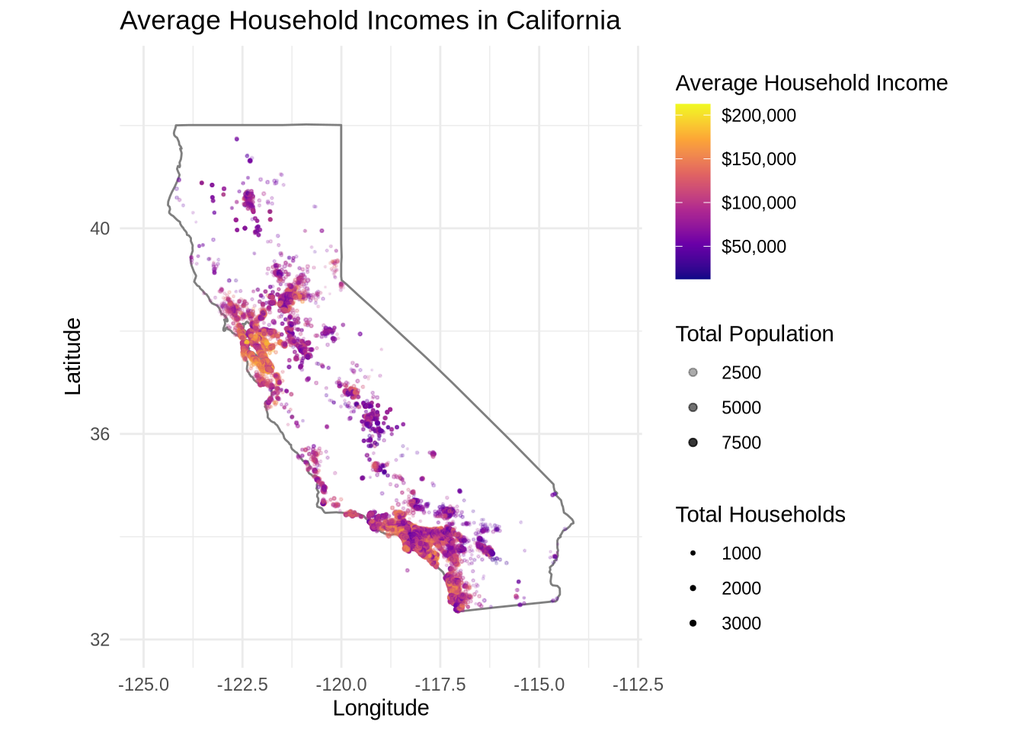

```r
ca_map <- map_data("state") |>
  subset(region == "california")
ggplot() +
  geom_polygon(data = ca_map, aes(x = long, y = lat, group = group),fill = "white",color = "gray50") +
  geom_point(data = ca_housing,
             aes(x = longitude, y = latitude,color = average_household_income,size=total_households , alpha=total_population)) +scale_size_area(max_size = 1) +
  scale_color_viridis_c(
    name = "Average Household Income",
    labels = dollar_format(),
    option = "plasma"
  ) +
  labs(
    title = "Average Household Incomes in California",
    x = "Longitude",
    y = "Latitude",
    size = 'Total Households',
    alpha = 'Total Population'
  ) +
  theme_minimal() +
  coord_fixed(
    xlim = c(-125, -113),
    ylim = c(32, 43),
    ratio = 1.3
  )
```

As shown above, we see that the more inland you go (in terms of longitude), the lower the household income is, whereas the closer to the coast one is, the higher the average household income is. This is due to most of California’s “high-paying” jobs are situated by the coasts: Silicon Valley, Hollywood, and the upcoming biomedical industry down in San Diego.

Additionally, here is a plot of median house values in California:

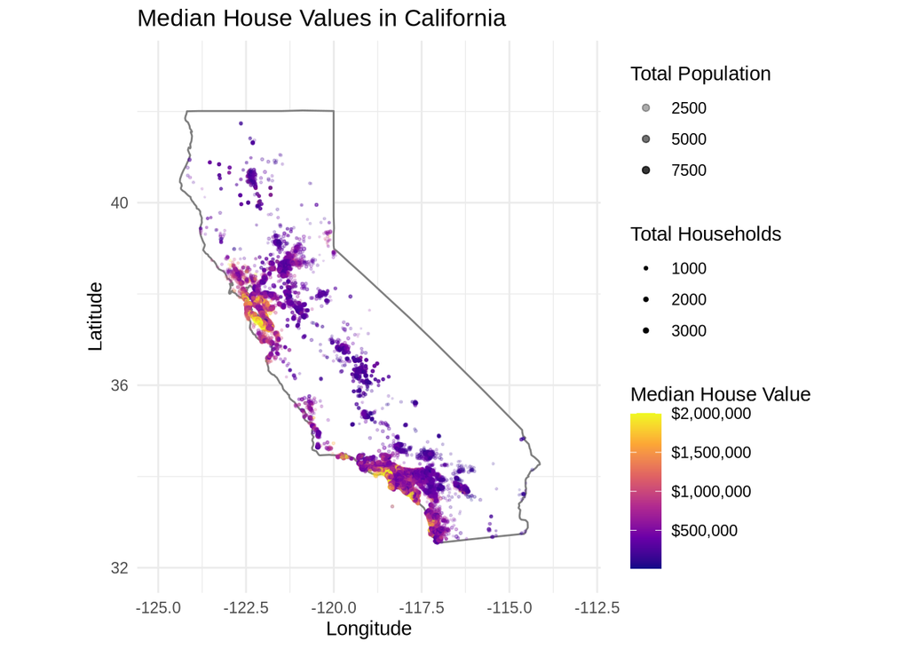

```r
ggplot() +
  geom_polygon(data = ca_map, aes(x = long, y = lat, group = group),fill = "white",color = "gray50") +
  geom_point(data = ca_housing,
             aes(x = longitude, y = latitude,color = median_house_value,size=total_households , alpha=total_population)) +scale_size_area(max_size = 1) +
  scale_color_viridis_c(
    name = "Median House Value",
    labels = dollar_format(),
    option = "plasma"
  ) +
  labs(
    title = "Median House Values in California",
    x = "Longitude",
    y = "Latitude",
    size = 'Total Households',
    alpha = 'Total Population'
  ) +
  theme_minimal() +
  coord_fixed(
    xlim = c(-125, -113),
    ylim = c(32, 43),
    ratio = 1.3
  )
```

Similar to the mapping of average household incomes, the median house values increase significantly the closer it gets to the coast. This suggests that the median housing value and average household income is correlated, given their similar patterns in geography.

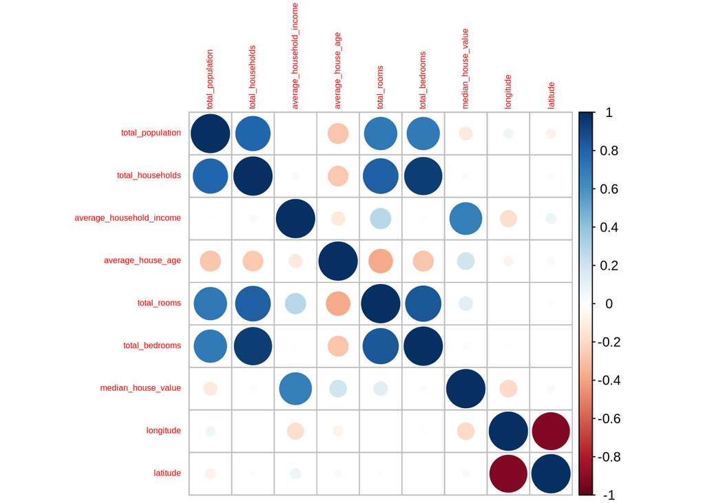

```r
ca_housing_cor <- cor(ca_housing |> dplyr::select_if(is.numeric))
corrplot::corrplot(ca_housing_cor, tl.cex = 0.5)
```

The correlation plot above further cements this, showing that `average_household_income` and `median_house_value` are stronger when it comes to determining the value of a house in California, suggesting that the higher someone makes annually, the more pricier their house may be.

```r
top_counties_by_house_value <- ca_housing |>
  filter(median_house_value >= 0) |>
  group_by(name) |>
  summarise(
    total_county_value = sum(median_house_value, na.rm = TRUE),
    average_county_house_value = mean(median_house_value, na.rm = TRUE),
    total_county_houses = n()
  ) |>
  arrange(desc(average_county_house_value)) |>
  slice_head(n = 10)

# Print the results
print(top_counties_by_house_value)
```

```
## # A tibble: 10 × 4
##    name            total_county_value average_county_house…¹ total_county_houses
##    <chr>                        <dbl>                  <dbl>               <int>
##  1 San Mateo Coun…          605041480               1281868.                 472
##  2 San Francisco …          705052059               1272657.                 554
##  3 Marin County             202481021               1191065.                 170
##  4 Santa Clara Co…         1261735439               1151218.                1096
##  5 Alameda County           846174813                819937.                1032
##  6 Santa Cruz Cou…          109165500                785363.                 139
##  7 Santa Barbara …          207231515                770377.                 269
##  8 Orange County           1359221055                753866.                1803
##  9 Napa County               77606403                739109.                 105
## 10 Contra Costa C…          476905204                701331.                 680
## # ℹ abbreviated name: ¹average_county_house_value
```

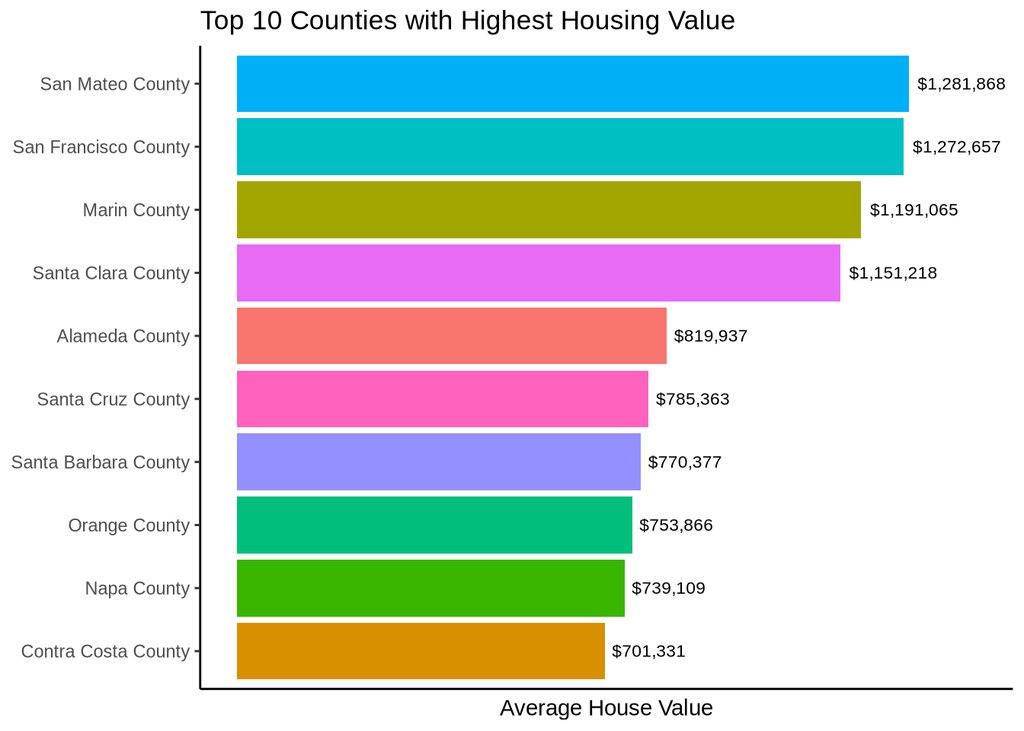

```r
top_counties_by_house_value |>
  ggplot(aes(x = reorder(name, average_county_house_value),
             y = average_county_house_value,
             fill = name)) +
  geom_bar(stat = "identity") +
  geom_text(aes(label = dollar(average_county_house_value)),
            hjust = -0.1,
            size = 3) +
  coord_flip() +
  labs(
    title = "Top 10 Counties with Highest Housing Value",
    x = "County",
    y = "Average House Value"
  ) +
  theme_classic() +
  theme(legend.position = "none",
        axis.ticks.x = element_blank(),
        axis.text.x = element_blank(),
        axis.title.y = element_blank()) +
  expand_limits(y = max(top_counties_by_house_value$average_county_house_value) * 1.1)
```

In the visualization, the top 10 counties with the highest average house values are displayed; based on this display, San Mateo County has the highest average value with approximately $1,281,868. According to the California county map, San Mateo County consists of primarily the Bay Area, excluding San Francisco; some of the cities included in the county are Pleasanton, Daly City, South San Francisco, and East Palo Alto.

## Analysis

In our analysis, we want to look at utilizing both linear regression and random forest algorithms, and comparing the results to determine which model is more accurate in predicting the price of a house in California with our provided dataset.

```r
# Refactoring county name and ocean_proximity
ca_housing <- ca_housing |>
  mutate(across(c(name, ocean_proximity), as.factor))

ca_housing <- ca_housing |>
  mutate(median_house_value = log(median_house_value))

#splitting the data into training and testing sets
ca_split <- rsample::initial_split(data = ca_housing, prop = 2/3)
train_ca <- rsample::training(ca_split)
test_ca <- rsample::testing(ca_split)

# Recipe for linear model
housing_rec <- recipe(train_ca) |>
    update_role(everything(), new_role = "predictor") |>
    update_role(median_house_value, new_role = "outcome") |>
    step_dummy(name, ocean_proximity, one_hot = TRUE) |>
    step_corr(all_numeric()) |>
    step_nzv(all_numeric())
```

First, variables `name` and `ocean_proximity` are refactored for the linear model, as these characteristics affect a house’s value. We then split the dataset into a training and testing set, and then applying a recipe to the housing training set. This recipe is loosely based on the recipe from CS02.

```r
prepped_rec <- prep(housing_rec, verbose = TRUE, retain = TRUE)
```

```
## oper 1 step dummy [training]
## oper 2 step corr [training]
## oper 3 step nzv [training]
## The retained training set is ~ 1.77 Mb  in memory.
```

```r
baked_train <- bake(prepped_rec, new_data = NULL)
baked_test_ca <- bake(prepped_rec, new_data = test_ca)

glimpse(baked_test_ca)
```

```
## Rows: 7,725
## Columns: 15
## $ total_population           <dbl> 1713, 1322, 1206, 1750, 2678, 748, 595, 150…
## $ total_households           <dbl> 644, 630, 423, 591, 1171, 241, 231, 758, 41…
## $ average_household_income   <dbl> 150520.19, 167222.22, 167677.30, 149141.29,…
## $ average_house_age          <dbl> 23.5, 16.7, 36.9, 37.4, 39.7, 40.1, 36.4, 2…
## $ total_rooms                <dbl> 5300, 4535, 2583, 3084, 6155, 1334, 1404, 3…
## $ median_house_value         <dbl> 14.30599, 13.93489, 14.18528, 14.03641, 13.…
## $ longitude                  <dbl> -122.2344, -122.2222, -122.2480, -122.2587,…
## $ name_Los.Angeles.County    <dbl> 0, 0, 0, 0, 0, 0, 0, 0, 0, 0, 0, 0, 0, 0, 0…
## $ name_Orange.County         <dbl> 0, 0, 0, 0, 0, 0, 0, 0, 0, 0, 0, 0, 0, 0, 0…
## $ name_Riverside.County      <dbl> 0, 0, 0, 0, 0, 0, 0, 0, 0, 0, 0, 0, 0, 0, 0…
## $ name_San.Diego.County      <dbl> 0, 0, 0, 0, 0, 0, 0, 0, 0, 0, 0, 0, 0, 0, 0…
## $ ocean_proximity_X.1H.OCEAN <dbl> 1, 0, 1, 1, 1, 0, 1, 0, 1, 1, 1, 0, 0, 0, 0…
## $ ocean_proximity_INLAND     <dbl> 0, 0, 0, 0, 0, 0, 0, 0, 0, 0, 0, 0, 0, 0, 0…
## $ ocean_proximity_NEAR.BAY   <dbl> 0, 1, 0, 0, 0, 1, 0, 1, 0, 0, 0, 1, 1, 1, 1…
## $ ocean_proximity_NEAR.OCEAN <dbl> 0, 0, 0, 0, 0, 0, 0, 0, 0, 0, 0, 0, 0, 0, 0…
```

Here, we bake the training dataset before fitting it to the linear model.

```r
lm_CA_model <- parsnip::linear_reg() |>
  parsnip::set_engine("lm") |>
  set_mode("regression")

CA_wflow <- workflows::workflow() |>
    workflows::add_recipe(housing_rec) |>
    workflows::add_model(lm_CA_model)

CA_wflow_fit <- fit(CA_wflow, data = train_ca)

wflowoutput <- CA_wflow_fit |>
  extract_fit_parsnip() |>
  broom::tidy()

wflowoutput
```

```
## # A tibble: 15 × 5
##    term                           estimate    std.error statistic    p.value
##    <chr>                             <dbl>        <dbl>     <dbl>      <dbl>
##  1 (Intercept)                 5.03         0.295         17.0     1.97e- 64
##  2 total_population           -0.000163     0.00000736   -22.1     2.12e-106
##  3 total_households            0.000602     0.0000299     20.1     1.13e- 88
##  4 average_household_income    0.0000132    0.000000117  112.      0
##  5 average_house_age           0.0133       0.000494      27.0     5.87e-157
##  6 total_rooms                 0.000000190  0.00000467     0.0407  9.68e-  1
##  7 longitude                  -0.0534       0.00248      -21.5     3.02e-101
##  8 name_Los.Angeles.County     0.419        0.0101        41.6     0
##  9 name_Orange.County          0.320        0.0142        22.5     1.25e-110
## 10 name_Riverside.County       0.151        0.0159         9.53    1.74e- 21
## 11 name_San.Diego.County       0.260        0.0143        18.2     6.04e- 73
## 12 ocean_proximity_X.1H.OCEAN -0.0264       0.0103        -2.56    1.04e-  2
## 13 ocean_proximity_INLAND     -0.148        0.00991      -15.0     2.50e- 50
## 14 ocean_proximity_NEAR.BAY    0.0988       0.0150         6.56    5.44e- 11
## 15 ocean_proximity_NEAR.OCEAN NA           NA             NA      NA
```

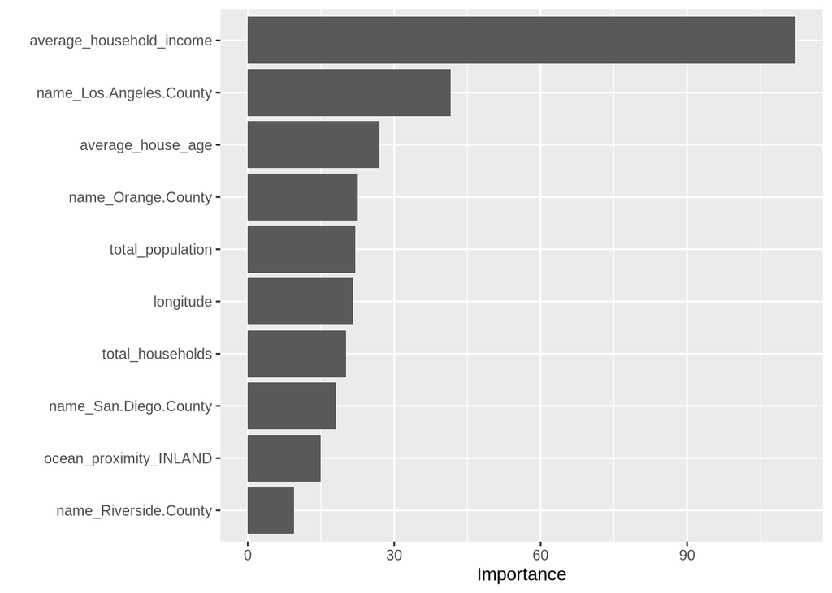

```r
CA_wflow_fit |>
  extract_fit_parsnip() |>
  vip::vip(num_features = 10)
```

After preparing and baking our training dataset with the previous recipe, we set our model to “Linear Regression” and then fit our dataset to the model. We then extract the top 10 features from the dataset that determine what features are the most important in determining house value. According to the output, we find that the most important feature in determining house value is `average_household_income`, which makes sense given that the more someone makes, the pricier their house may be.

```r
wf_fit <- CA_wflow_fit |>
  extract_fit_parsnip()

wf_fitted_values <-
  broom::augment(wf_fit[["fit"]], data = baked_train) |>
  select(median_house_value, .fitted:.std.resid)


yardstick::metrics(wf_fitted_values,
                   truth = median_house_value, estimate = .fitted)
```

```
## # A tibble: 3 × 3
##   .metric .estimator .estimate
##   <chr>   <chr>          <dbl>
## 1 rmse    standard       0.379
## 2 rsq     standard       0.655
## 3 mae     standard       0.275
```

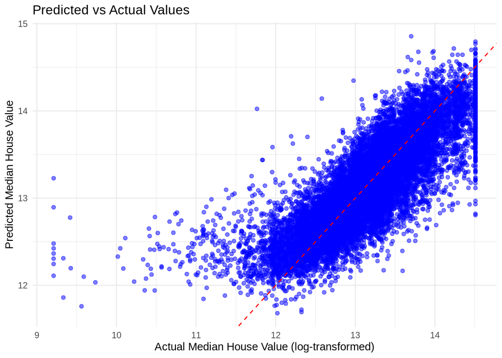

```r
ggplot(wf_fitted_values, aes(x = median_house_value, y = .fitted)) +
  geom_point(alpha = 0.5, color = "blue") +  # Scatter plot points
  geom_abline(slope = 1, intercept = 0, color = "red", linetype = "dashed") +  # Perfect prediction line
  labs(
    title = "Predicted vs Actual Values",
    x = "Actual Median House Value (log-transformed)",
    y = "Predicted Median House Value"
  ) +
  theme_minimal()
```

```r
# Re-filtering the data to only consider less affluent housing prices.
price_threshold <- quantile(ca_housing$median_house_value, 0.97)
ca_housing <- ca_housing %>%
  filter(median_house_value <= price_threshold)
#Log transforming to get a better distribution
#ca_housing <- ca_housing |>
   #mutate(median_house_value = log(median_house_value))

# Re-splitting the data into training and testing sets
ca_split <- rsample::initial_split(data = ca_housing, prop = 2/3)
train_ca <- rsample::training(ca_split)
test_ca <- rsample::testing(ca_split)

housing_rec <- recipe(train_ca) |>
    update_role(everything(), new_role = "predictor") |>
    update_role(median_house_value, new_role = "outcome") |>
    step_dummy(name, ocean_proximity, one_hot = TRUE) |>
    step_corr(all_numeric()) |>
    step_nzv(all_numeric())
```

Here, we re-run the model, applying the previous explanation of looking at all housing values (at most) in the 97th percentile.

```r
# Prepping and training the model
prepped_rec <- prep(housing_rec, verbose = TRUE, retain = TRUE)
```

```
## oper 1 step dummy [training]
## oper 2 step corr [training]
## oper 3 step nzv [training]
## The retained training set is ~ 1.83 Mb  in memory.
```

```r
baked_train <- bake(prepped_rec, new_data = NULL)
baked_test_ca <- bake(prepped_rec, new_data = test_ca)

lm_CA_model <- parsnip::linear_reg() |>
  parsnip::set_engine("lm") |>
  set_mode("regression")

CA_wflow <- workflows::workflow() |>
    workflows::add_recipe(housing_rec) |>
    workflows::add_model(lm_CA_model)

CA_wflow_fit <- fit(CA_wflow, data = train_ca)

wflowoutput <- CA_wflow_fit |>
  extract_fit_parsnip() |>
  broom::tidy()

wflowoutput
```

```
## # A tibble: 16 × 5
##    term                          estimate    std.error statistic    p.value
##    <chr>                            <dbl>        <dbl>     <dbl>      <dbl>
##  1 (Intercept)                 4.85        0.326          14.9    1.08e- 49
##  2 total_population           -0.000137    0.00000743    -18.5    1.56e- 75
##  3 total_households            0.000592    0.0000305      19.4    1.42e- 82
##  4 average_household_income    0.0000127   0.000000120   106.     0
##  5 average_house_age           0.0126      0.000498       25.3    7.90e-138
##  6 total_rooms                -0.00000883  0.00000480     -1.84   6.60e-  2
##  7 longitude                  -0.0551      0.00273       -20.2    1.41e- 89
##  8 name_Los.Angeles.County     0.412       0.0110         37.4    1.88e-292
##  9 name_Orange.County          0.321       0.0148         21.6    5.09e-102
## 10 name_Riverside.County       0.146       0.0168          8.69   4.11e- 18
## 11 name_San.Bernardino.County  0.00992     0.0161          0.614  5.39e-  1
## 12 name_San.Diego.County       0.275       0.0151         18.2    4.57e- 73
## 13 ocean_proximity_X.1H.OCEAN -0.0185      0.0104         -1.79   7.35e-  2
## 14 ocean_proximity_INLAND     -0.142       0.00999       -14.2    1.82e- 45
## 15 ocean_proximity_NEAR.BAY    0.0917      0.0156          5.87   4.36e-  9
## 16 ocean_proximity_NEAR.OCEAN NA          NA              NA     NA
```

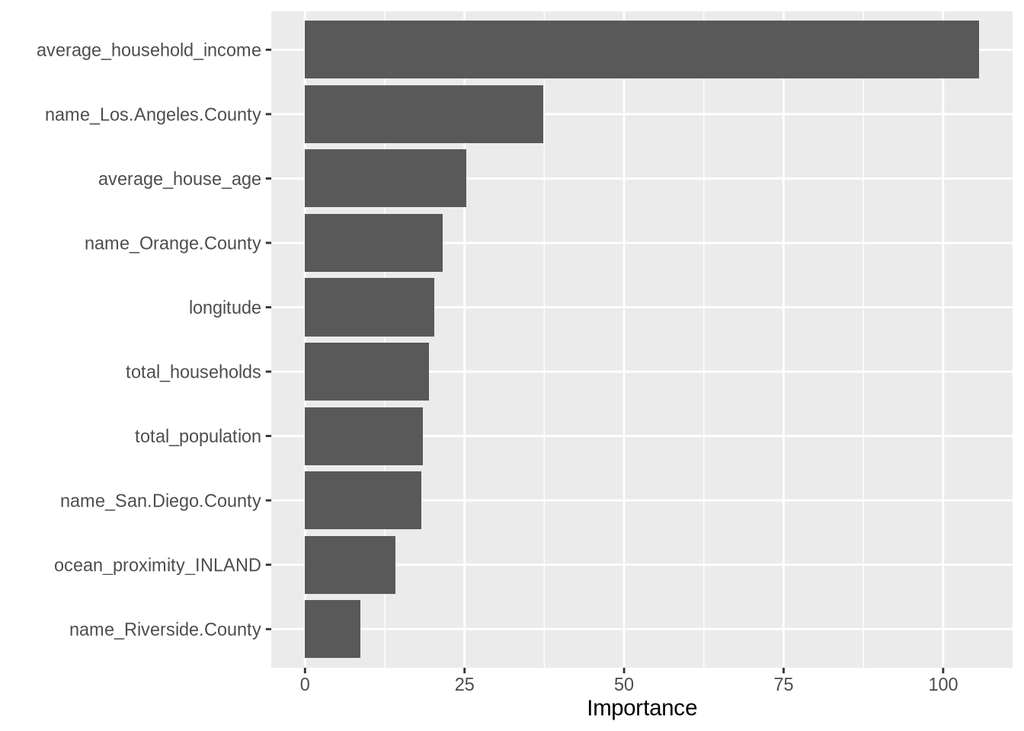

```r
CA_wflow_fit |>
  extract_fit_parsnip() |>
  vip::vip(num_features = 10)
```

```r
# Looking at the results from excluding anything above the 97th percentile
wf_fit <- CA_wflow_fit |>
  extract_fit_parsnip()

wf_fitted_values <-
  broom::augment(wf_fit[["fit"]], data = baked_train) |>
  select(median_house_value, .fitted:.std.resid)


yardstick::metrics(wf_fitted_values, truth = median_house_value, estimate = .fitted)
```

```
## # A tibble: 3 × 3
##   .metric .estimator .estimate
##   <chr>   <chr>          <dbl>
## 1 rmse    standard       0.377
## 2 rsq     standard       0.621
## 3 mae     standard       0.269
```

In order to make a comparison to the linear regression model above, we apply our dataset to a Random Forest algorithm; however, we include all parts of the dataset (> 97th percentile) to see the general accuracy.

```r
ca_housing <- read_csv("data/california_housing_updated.csv")
ca_housing <- ca_housing[!apply(ca_housing == -666666666, 1, any), ]
# Refactoring county name and ocean_proximity
ca_housing <- ca_housing |>
  mutate(across(c(name, ocean_proximity), as.factor))

# Splitting the data into training and testing sets
ca_split <- rsample::initial_split(data = ca_housing, prop = 2/3)
train_ca <- rsample::training(ca_split)
test_ca <- rsample::testing(ca_split)

RF_rec <- recipe(train_ca) |>
    update_role(everything(), new_role = "predictor") %>%
    update_role(median_house_value, new_role = "outcome") %>%
    step_string2factor("ocean_proximity") %>%
    step_dummy(all_nominal_predictors()) %>%
    # Handle correlation
    step_corr(all_numeric(), threshold = 0.8) %>%
    # Remove near-zero variance
    step_nzv(all_numeric()) %>%
    # Normalize numeric predictors
    step_normalize(all_numeric_predictors())

# install.packages("randomForest")
tune_RF_model <- rand_forest(mtry = tune(), min_n = tune()) |>
  set_engine("randomForest") |>
  set_mode("regression")

tune_RF_model
```

```
## Random Forest Model Specification (regression)
##
## Main Arguments:
##   mtry = tune()
##   min_n = tune()
##
## Computational engine: randomForest
```

```r
# Using Cross-fold validation for better model performance.
vfold_ca <- rsample::vfold_cv(data = train_ca, v = 4)

RF_tune_wflow <- workflows::workflow() |>
  workflows::add_recipe(RF_rec) |>
  workflows::add_model(tune_RF_model)

n_cores <- parallel::detectCores()
doParallel::registerDoParallel(cores = n_cores)
tune_RF_results <- tune_grid(object = RF_tune_wflow, resamples=vfold_ca, grid = 20)
tune_RF_results
```

```
## # Tuning results
## # 4-fold cross-validation
## # A tibble: 4 × 4
##   splits               id    .metrics          .notes
##   <list>               <chr> <list>            <list>
## 1 <split [11587/3863]> Fold1 <tibble [40 × 6]> <tibble [0 × 3]>
## 2 <split [11587/3863]> Fold2 <tibble [40 × 6]> <tibble [0 × 3]>
## 3 <split [11588/3862]> Fold3 <tibble [40 × 6]> <tibble [0 × 3]>
## 4 <split [11588/3862]> Fold4 <tibble [40 × 6]> <tibble [1 × 3]>
##
## There were issues with some computations:
##
##   - Warning(s) x1: the standard deviation is zero, The correlation matrix has missin...
##
## Run `show_notes(.Last.tune.result)` for more information.
```

Here, we utilize a similar formula as the Linear Regression model, but adjusting the algorithm used, and adjusting the recipe according to the Random Forest implementation.

```r
tune_RF_results |>
  collect_metrics()
```

```
## # A tibble: 40 × 8
##     mtry min_n .metric .estimator       mean     n    std_err .config
##    <int> <int> <chr>   <chr>           <dbl> <int>      <dbl> <chr>
##  1     4    39 rmse    standard   226228.        4 4928.      Preprocessor1_Mod…
##  2     4    39 rsq     standard        0.703     4    0.00593 Preprocessor1_Mod…
##  3     6    15 rmse    standard   222977.        4 5178.      Preprocessor1_Mod…
##  4     6    15 rsq     standard        0.709     4    0.00729 Preprocessor1_Mod…
##  5     8    31 rmse    standard   225946.        4 5446.      Preprocessor1_Mod…
##  6     8    31 rsq     standard        0.701     4    0.00806 Preprocessor1_Mod…
##  7     3    19 rmse    standard   229811.        4 5144.      Preprocessor1_Mod…
##  8     3    19 rsq     standard        0.699     4    0.00579 Preprocessor1_Mod…
##  9     7    28 rmse    standard   224745.        4 5230.      Preprocessor1_Mod…
## 10     7    28 rsq     standard        0.704     4    0.00763 Preprocessor1_Mod…
## # ℹ 30 more rows
```

```r
show_best(tune_RF_results, metric = "rmse", n = 1)
```

```
## # A tibble: 1 × 8
##    mtry min_n .metric .estimator    mean     n std_err .config
##   <int> <int> <chr>   <chr>        <dbl> <int>   <dbl> <chr>
## 1     5     7 rmse    standard   222035.     4   5078. Preprocessor1_Model20
```

### Final Model Evaluation

```r
tuned_RF_values<- select_best(tune_RF_results)
tuned_RF_values
```

```
## # A tibble: 1 × 3
##    mtry min_n .config
##   <int> <int> <chr>
## 1     5     7 Preprocessor1_Model20
```

```r
# specify best combination from tune in workflow
RF_tuned_wflow <-RF_tune_wflow |>
  tune::finalize_workflow(tuned_RF_values)

# fit model with those parameters on train AND test
overallfit <- RF_tuned_wflow |>
  tune::last_fit(ca_split)

collect_metrics(overallfit)
```

```
## # A tibble: 2 × 4
##   .metric .estimator  .estimate .config
##   <chr>   <chr>           <dbl> <chr>
## 1 rmse    standard   224931.    Preprocessor1_Model1
## 2 rsq     standard        0.692 Preprocessor1_Model1
```

```r
test_predictions <- collect_predictions(overallfit)
```

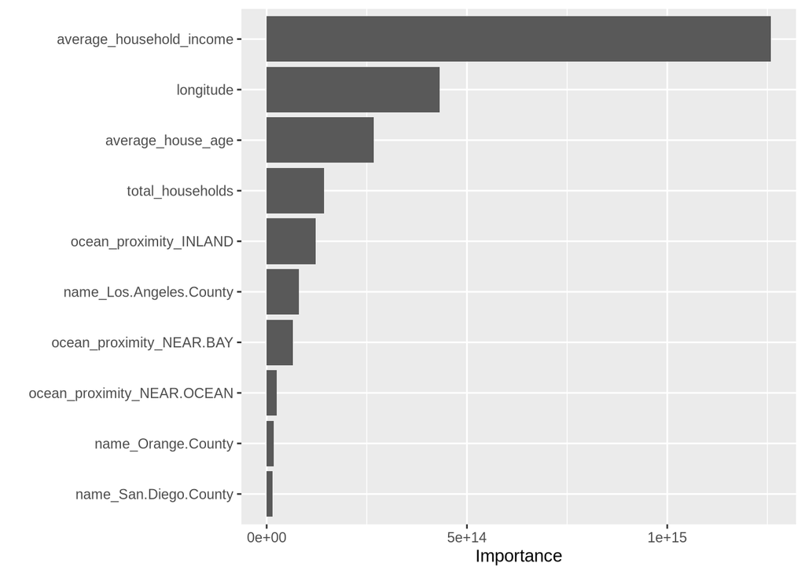

```r
overallfit |>
  extract_fit_parsnip() |>
  vip::vip(num_features = 10)
```

```r
# fit data
RF_final_train_fit <- parsnip::fit(RF_tuned_wflow, data = train_ca)
RF_final_test_fit <- parsnip::fit(RF_tuned_wflow, data = test_ca)

# get predictions on training data
values_pred_train <- predict(RF_final_train_fit, train_ca) |>
  bind_cols(train_ca |> select(median_house_value, name, ocean_proximity))

# get predictions on testing data
values_pred_test <- predict(RF_final_test_fit, test_ca) |>
  bind_cols(test_ca |> select(median_house_value, name, ocean_proximity))
```

After running the Random Forest model on both the training and testing data, and selecting `median_house_value`, `name`, and `ocean_proximity`, we find the most important feature continues to remain `average_household_income`, followed by `longitude` and `average_house_age`.

## Overall Results

### Linear Regression Model Results

[figure not shown]

```r
wf_fitted_values |>
  ggplot(aes(x =  median_house_value, y = .fitted)) +
  geom_point(alpha = 0.5, color = "#2C3E50") +
  geom_abline(intercept = 0, slope = 1, color = "red", linetype = "dashed", size = 1) +
  labs(
    title = "Predicted vs. Actual Median House Values",
    subtitle = "Perfect predictions would fall on the dashed red line",
    x = "Predicted Values ($)",
    y = "Actual Values ($)",
    caption = "Model used is linear regression"
  ) +
  theme_minimal() +
  theme(
    plot.title = element_text(size = 14, face = "bold"),
    plot.subtitle = element_text(size = 10, color = "gray40"),
    panel.grid.major = element_line(color = "gray90"),
    panel.grid.minor = element_line(color = "gray95"),
    axis.text = element_text(size = 10),
    axis.title = element_text(size = 12)
  )
```

```r
yardstick::metrics(wf_fitted_values, truth = median_house_value, estimate = .fitted)
```

```
## # A tibble: 3 × 3
##   .metric .estimator .estimate
##   <chr>   <chr>          <dbl>
## 1 rmse    standard       0.377
## 2 rsq     standard       0.621
## 3 mae     standard       0.269
```

### Random Forest Model Results

This is our graph of actual values of median house value versus the predicted values in our RF model.

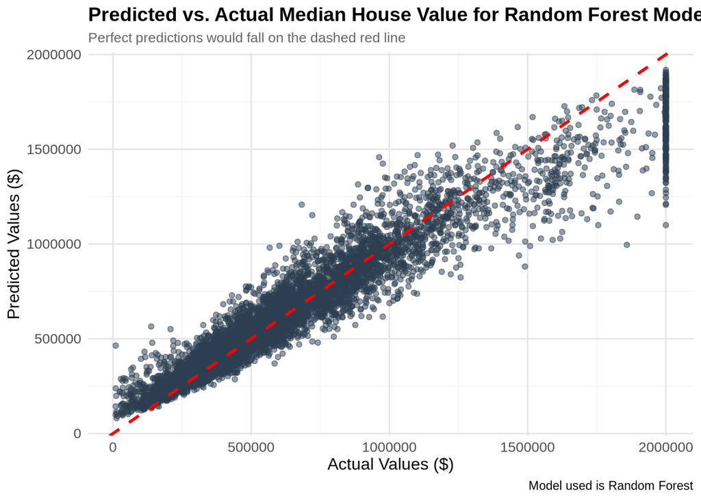

```r
ggplot(values_pred_test, aes(x=median_house_value, y=.pred))+
  geom_point(alpha = 0.5, color = "#2C3E50") +
  geom_abline(intercept = 0, slope = 1, color = "red", linetype = "dashed", size = 1) +
  labs(
    title = "Predicted vs. Actual Median House Value for Random Forest Modelling",
    subtitle = "Perfect predictions would fall on the dashed red line",
    x = "Actual Values ($)",
    y = "Predicted Values ($)",
    caption = "Model used is Random Forest"
  ) +
  theme_minimal() +
  theme(
    plot.title = element_text(size = 14, face = "bold"),
    plot.subtitle = element_text(size = 10, color = "gray40"),
    panel.grid.major = element_line(color = "gray90"),
    panel.grid.minor = element_line(color = "gray95"),
    axis.text = element_text(size = 10),
    axis.title = element_text(size = 12)
  )
```

```r
collect_metrics(overallfit)
```

```
## # A tibble: 2 × 4
##   .metric .estimator  .estimate .config
##   <chr>   <chr>           <dbl> <chr>
## 1 rmse    standard   224931.    Preprocessor1_Model1
## 2 rsq     standard        0.692 Preprocessor1_Model1
```

## Discussion

Overall, the important features of each model remain relatively the same across the board, with `average_household_income` remaining the dominant feature for both Linear Regression and Random Forest. For both models, this dominant feature makes sense given that most individuals with a high household income would typically have pricier living conditions (and vice versa). This is visible in the EDA, where both `median_housing_value` and `average_household_income` are concentrated within certain areas such as the Bay Area and San Diego. More so, `ocean_proximity` does also play a significant part in both Linear Regression and Random Forest, as most “beachfront” and “bay-front” properties are often pricier than most houses, given their prime locations in the state.

## Conclusion

The model performances highlight the dataset’s complexity, particularly in capturing high-value property variations (as shown with the several outliers). Although the Random Forest model showed superior explanatory power, both models consistently identified key predictors such as `average_household_income` and `ocean_proximity` as critical factors influencing house values. These findings not only provide insights into California’s housing market dynamics, but also demonstrate the potential of machine learning techniques in real estate price prediction.

Future research could focus on addressing the models’ limitations, particularly their challenges with high-value property outliers, potentially through advanced techniques like XGBoost or GMMs.

## References

[^1]: Tikkanen, A. (2024, January 17). *list of U.S. states by population. Encyclopedia Britannica.* https://www.britannica.com/topic/largest-U-S-state-by-population
[^2]: *California’s Population is Increasing.* (2024, April 30). California Governor; CAWeb Publishing Service. https://www.gov.ca.gov/2024/04/30/californias-population-is-increasing/.
[^3]: Zillow. (2024). *San Francisco, CA Housing Market*. https://www.zillow.com/home-values/20330/san-francisco-ca/.
[^4]: Bohn, S., & Duan, J. (2024, October 14). *California’s Economy.* Public Policy Institute of California. https://www.ppic.org/publication/californias-economy/.
[^5]: Nicolaides, B. M. (2023). The Historic Suburban Landscapes of Los Angeles. *Oxford University Press EBooks, 19–68.* https://doi.org/10.1093/oso/9780197578308.003.0002